# Complete Analytical Report: Historical Climate Series of Piracicaba

LCF5900 - Open Science and Reproducible Data

Ricardo Antonio Ruiz-Cardozo

2026-06-01

## Introduction

This document reflects the complete workflow of open data analysis for the **LCF5900** course. Here, we present 15 analytical steps, starting from raw data extraction to the application of non-parametric tests and *Machine Learning* projections with the **Prophet** algorithm, ensuring transparency and reproducibility (*Open Science*).

## 1. Setup and Memory Cleanup

We start by ensuring that the R environment is clean and ready for processing.

```r
rm(list=ls(all=TRUE))
gc()
```

```
##           used (Mb) gc trigger (Mb) max used (Mb)
## Ncells  625739 33.5    1436721 76.8   702071 37.5
## Vcells 1169575  9.0    8388608 64.0  1927961 14.8
```

```r
# Loading essential packages
library(tidyverse)
library(rio)
library(lubridate)
library(zoo)
library(ggcorrplot)
library(prophet)
```

## 2. Data Import

We connect directly to the public repository on GitHub to extract the dataset in its original state.

```r
url_1   <- "https://github.com/raruizc/ClimateTimeSeriesPiracicaba/blob/main/"
xls_2   <- "DadosClima_Piracicaba.xlsx"
prm_3   <- "?raw=true"
gitFile <- paste0(url_1, xls_2, prm_3)

my_col_types <- c(rep("text", 8), rep("numeric", 16))
sheetName    <- "DadosClima_Piracicaba"
df <- import(gitFile, which = sheetName, col_types = my_col_types)
df <- df %>% mutate(across(4:8, factor)) %>% tibble()
df$TMED <- as.numeric(df$TMED)
```

## 3. General Data Preparation

We create the `Data` variable and filter the historical series from 1950 onwards, ensuring data density and record reliability.

```r
df_clima <- df %>%
  mutate(
    Data    = make_date(Ano, Mes, Dia),
    TMAX    = as.numeric(TMAX),
    Estacao = as.factor(Estacao)
  ) %>%
  drop_na(TMAX, Estacao)

df_recente <- df_clima %>% filter(Ano >= 1950)
```

## 4. Descriptive Analysis: Maximum Temperature

Basic statistics of TMAX segmented by seasons of the year.

```r
tabela_descritiva <- df_recente %>%
  group_by(Estacao) %>%
  summarise(
    Mean_TMAX         = round(mean(TMAX, na.rm = TRUE), 1),
    Max_Peak          = max(TMAX, na.rm = TRUE),
    Min_Registered    = min(TMAX, na.rm = TRUE),
    Standard_Dev      = round(sd(TMAX, na.rm = TRUE), 2)
  )

print(tabela_descritiva)
```

```
## # A tibble: 4 × 5
##   Estacao   Mean_TMAX Max_Peak Min_Registered Standard_Dev
##   <fct>         <dbl>    <dbl>          <dbl>        <dbl>
## 1 Inverno        27       39.6           11.8         4.18
## 2 Outono         27.2     35.7           11.6         3.52
## 3 Primavera      29.8     41.2           16           3.76
## 4 Verão          30.5     39.6           18.5         2.93
```

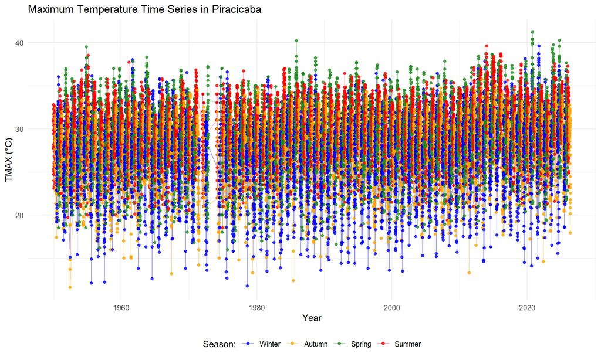

```r
ggplot(df_recente, aes(x = Data, y = TMAX, color = Estacao)) +
  geom_line(alpha = 0.4) + geom_point(size = 1.5, alpha = 0.8) +
  # Keeping the Portuguese keys to match the dataset, but translating the legend
  scale_color_manual(name = "Season:",
                     labels = c("Verão" = "Summer", "Outono" = "Autumn",
                                "Inverno" = "Winter", "Primavera" = "Spring"),
                     values = c("Verão" = "red", "Outono" = "orange",
                                "Inverno" = "blue", "Primavera" = "forestgreen")) +
  labs(title = "Maximum Temperature Time Series in Piracicaba",
       x = "Year", y = "TMAX (°C)") +
  theme_minimal() + theme(legend.position = "bottom")
```

**Interpretation:** The series reveals strong thermal oscillation. Winter, despite having the lowest average, presents the highest standard deviation, harboring extreme heat days close to 40°C.

## 5. Area Chart: Thermal Amplitude

Visualizing the “width” of the daily temperature range (Minimum to Maximum).

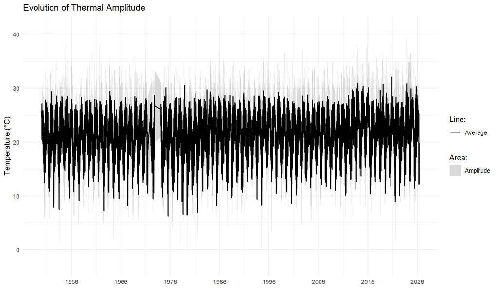

```r
df_plot_area <- df_recente %>%
  mutate(TMED = as.numeric(TMED), TMAX = as.numeric(TMAX), TMIN = as.numeric(TMIN)) %>%
  drop_na(Data, TMED, TMAX, TMIN)

ggplot(df_plot_area) +
  geom_ribbon(aes(x = Data, ymin = TMIN, ymax = TMAX, fill = "Amplitude"), alpha = 0.3) +
  geom_line(aes(x = Data, y = TMED, color = "Average"), linewidth = 0.8) +
  scale_color_manual(name = "Line:", values = c("Average" = "black")) +
  scale_fill_manual(name = "Area:", values = c("Amplitude" = "grey50")) +
  labs(title = "Evolution of Thermal Amplitude", x = "", y = "Temperature (°C)") +
  scale_x_date(date_labels = "%Y", date_breaks = "10 years") + theme_minimal()
```

## 6. Simple Time Series of Rain

Observing the raw volume of rainfall over time.

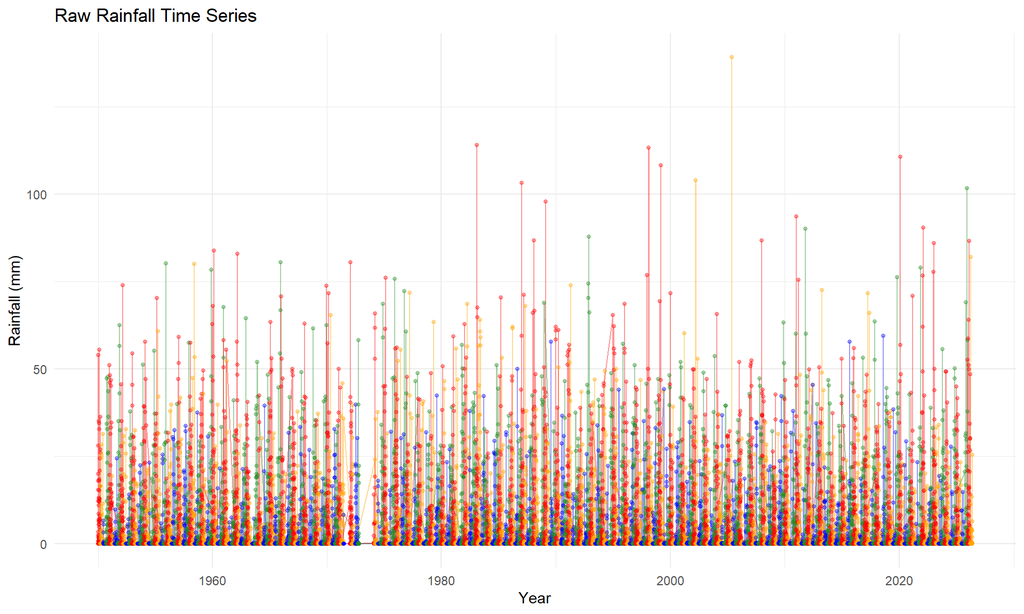

```r
ggplot(df_recente, aes(x = Data, y = as.numeric(Chuva), color = Estacao)) +
  geom_line(alpha = 0.4) + geom_point(size = 1, alpha = 0.4) +
  scale_color_manual(values = c("Verão" = "red", "Outono" = "orange",
                                "Inverno" = "blue", "Primavera" = "forestgreen")) +
  labs(title = "Raw Rainfall Time Series", x = "Year", y = "Rainfall (mm)") +
  theme_minimal() + theme(legend.position = "none")
```

## 7. Moving Average of Precipitation by Quarter

To isolate the noise of daily rain, we applied a 30-day moving average partitioned by quarter, sorted chronologically.

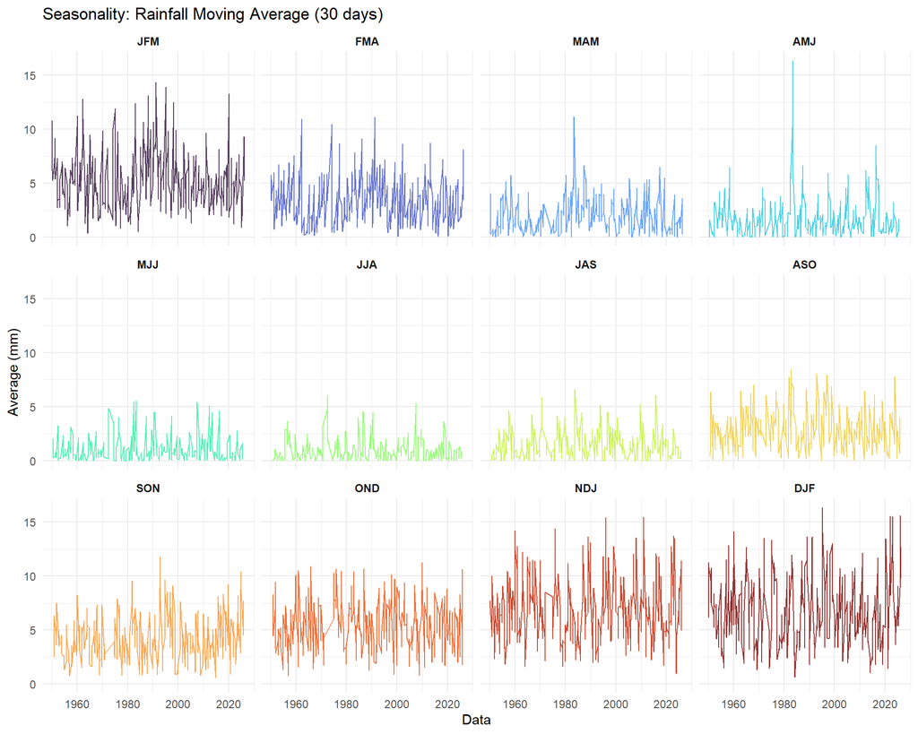

```r
ordem_trimestres <- c("JFM", "FMA", "MAM", "AMJ", "MJJ", "JJA", "JAS",
                      "ASO", "SON", "OND", "NDJ", "DJF")

df_chuva <- df_recente %>%
  mutate(Chuva = as.numeric(Chuva), Trimestre = factor(Trimestre, levels = ordem_trimestres)) %>%
  arrange(Data) %>%
  mutate(Chuva_Movel_30d = rollmean(Chuva, k = 30, fill = NA, align = "right")) %>%
  drop_na(Chuva_Movel_30d, Trimestre)

ggplot(df_chuva, aes(x = Data, y = Chuva_Movel_30d, color = Trimestre)) +
  geom_line(alpha = 0.8) + facet_wrap(~Trimestre, ncol = 4) +
  scale_color_viridis_d(option = "turbo") +
  labs(title = "Seasonality: Rainfall Moving Average (30 days)", y = "Average (mm)") +
  theme_minimal() + theme(legend.position = "none", strip.text = element_text(face = "bold"))
```

**Interpretation:** This proves the severe drought in the middle of the year (JJA/JAS) and the torrential summers (DJF/JFM) in Piracicaba.

## 8. Exploratory Analysis of the ENSO Phenomenon (ClassNino)

Relationship between El Niño / La Niña phases and the maximum temperature in the city.

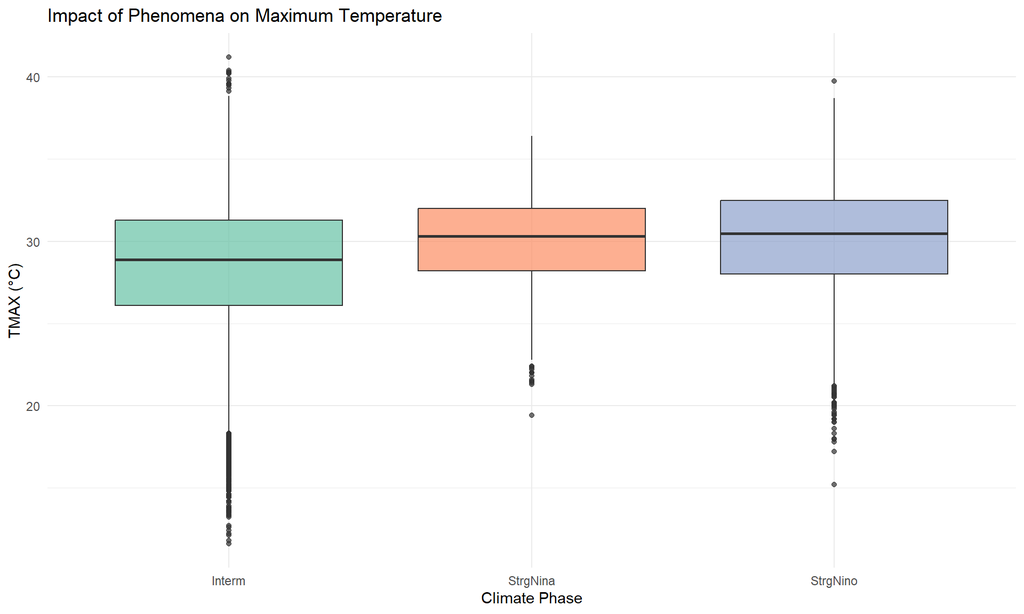

```r
df_nino <- df_clima %>% filter(!is.na(ClassNino) & ClassNino != "") %>%
  mutate(ClassNino = as.factor(ClassNino))

ggplot(df_nino, aes(x = ClassNino, y = TMAX, fill = ClassNino)) +
  geom_boxplot(alpha = 0.7) + scale_fill_brewer(palette = "Set2") +
  labs(title = "Impact of Phenomena on Maximum Temperature",
       x = "Climate Phase", y = "TMAX (°C)") +
  theme_minimal() + theme(legend.position = "none")
```

## 9. Statistics: ENSO Influence on Rainfall (Complete Series)

Non-parametric Kruskal-Wallis test (robust alternative to ANOVA).

```r
df_chuva_nino <- df_clima %>% filter(!is.na(ClassNino) & ClassNino != "", !is.na(Chuva)) %>%
  mutate(ClassNino = as.factor(ClassNino), Chuva = as.numeric(Chuva))

kruskal.test(Chuva ~ ClassNino, data = df_chuva_nino)
```

```
##
##  Kruskal-Wallis rank sum test
##
## data:  Chuva by ClassNino
## Kruskal-Wallis chi-squared = 308.4, df = 2, p-value < 2.2e-16
```

## 10. Extra Statistics: Influence on Summer Rainfall

Isolating the rainy months to prevent the winter drought from masking the oceanic impact.

```r
df_verao <- df_clima %>% filter(Estacao == "Verão", !is.na(ClassNino),
                                ClassNino != "", !is.na(Chuva)) %>%
  mutate(ClassNino = as.factor(ClassNino), Chuva = as.numeric(Chuva))

kruskal.test(Chuva ~ ClassNino, data = df_verao)
```

```
##
##  Kruskal-Wallis rank sum test
##
## data:  Chuva by ClassNino
## Kruskal-Wallis chi-squared = 13.512, df = 2, p-value = 0.001164
```

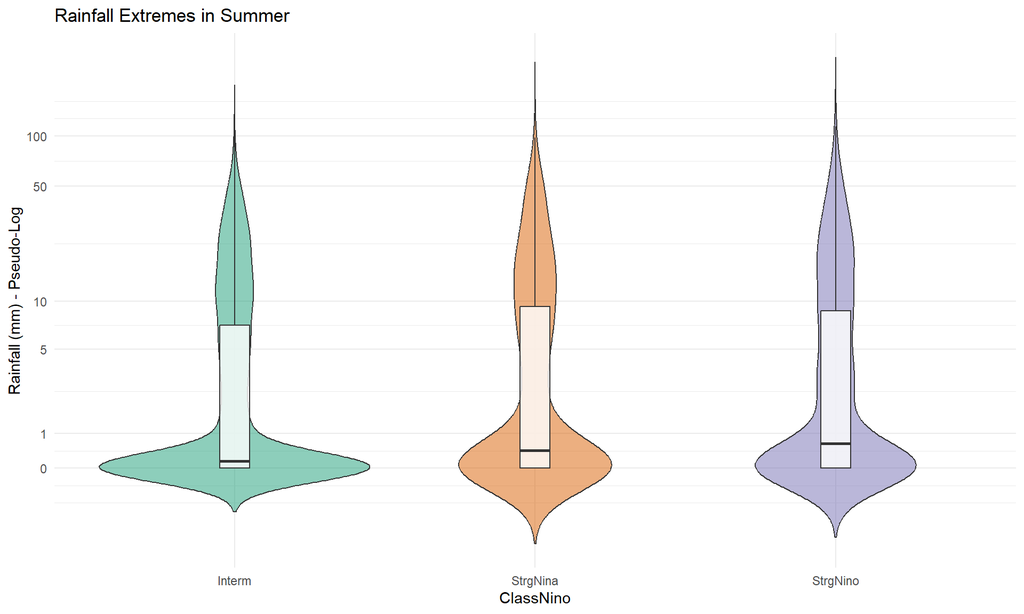

```r
ggplot(df_verao, aes(x = ClassNino, y = Chuva, fill = ClassNino)) +
  geom_violin(alpha = 0.5, trim = FALSE) +
  geom_boxplot(width = 0.1, fill = "white", alpha = 0.8) +
  scale_y_continuous(trans = "pseudo_log", breaks = c(0, 1, 5, 10, 50, 100)) +
  scale_fill_brewer(palette = "Dark2") +
  labs(title = "Rainfall Extremes in Summer", y = "Rainfall (mm) - Pseudo-Log") +
  theme_minimal() + theme(legend.position = "none")
```

## 11. Correlation Analysis (Spearman)

Ideal for dealing with variables that do not follow a normal distribution and have many climatic *outliers*.

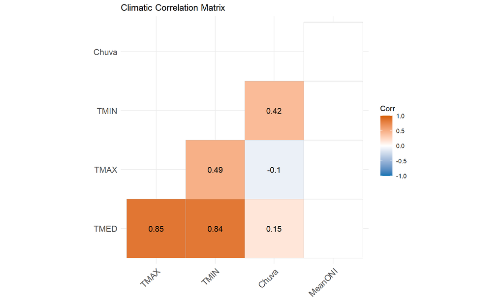

```r
df_cor <- df_recente %>% select(TMED, TMAX, TMIN, Chuva, MeanONI) %>%
  mutate(across(everything(), as.numeric)) %>% drop_na()
matriz_cor <- cor(df_cor, method = "spearman")
p_mat <- cor_pmat(df_cor, method = "spearman")

ggcorrplot(matriz_cor, method = "square", type = "lower", lab = TRUE,
           p.mat = p_mat, sig.level = 0.05, insig = "blank",
           colors = c("#0072B2", "white", "#D55E00"),
           title = "Climatic Correlation Matrix")
```

## 12. Times of Thermal Extremes

Categorizing continuous data to answer: In what period of the day do absolute peaks of heat and cold occur?

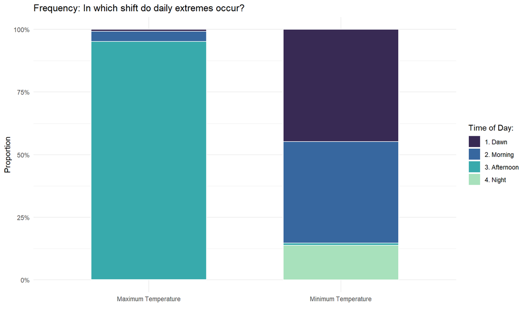

```r
df_horas <- df_recente %>%
  drop_na(TMAX_hora, TMIN_hora) %>%
  mutate(
    Hora_TMAX = floor(as.numeric(TMAX_hora) / 100), Hora_TMIN = floor(as.numeric(TMIN_hora) / 100),
    Periodo_TMAX = case_when(Hora_TMAX >= 0 & Hora_TMAX < 6 ~ "1. Dawn",
                             Hora_TMAX >= 6 & Hora_TMAX < 12 ~ "2. Morning",
                             Hora_TMAX >= 12 & Hora_TMAX < 18 ~ "3. Afternoon",
                             Hora_TMAX >= 18 & Hora_TMAX <= 24 ~ "4. Night",
                             TRUE ~ NA_character_),
    Periodo_TMIN = case_when(Hora_TMIN >= 0 & Hora_TMIN < 6 ~ "1. Dawn",
                             Hora_TMIN >= 6 & Hora_TMIN < 12 ~ "2. Morning",
                             Hora_TMIN >= 12 & Hora_TMIN < 18 ~ "3. Afternoon",
                             Hora_TMIN >= 18 & Hora_TMIN <= 24 ~ "4. Night",
                             TRUE ~ NA_character_)
  ) %>% drop_na(Periodo_TMAX, Periodo_TMIN)

df_horas_long <- df_horas %>% select(Data, Periodo_TMAX, Periodo_TMIN) %>%
  pivot_longer(cols = c(Periodo_TMAX, Periodo_TMIN), names_to = "Tipo",
               values_to = "Periodo") %>%
  mutate(Tipo = recode(Tipo, "Periodo_TMAX" = "Maximum Temperature",
                       "Periodo_TMIN" = "Minimum Temperature"))

ggplot(df_horas_long, aes(x = Tipo, fill = Periodo)) +
  geom_bar(position = "fill", color = "white", width = 0.6) +
  scale_y_continuous(labels = scales::percent_format()) +
  scale_fill_viridis_d(option = "mako", begin = 0.2, end = 0.9) +
  labs(title = "Frequency: In which shift do daily extremes occur?",
       x = "", y = "Proportion", fill = "Time of Day:") + theme_minimal()
```

## 13. History of the ONI Index (NOAA Style)

The “breathing” of the Equatorial Pacific Ocean and the alternation between warming (El Niño) and cooling (La Niña).

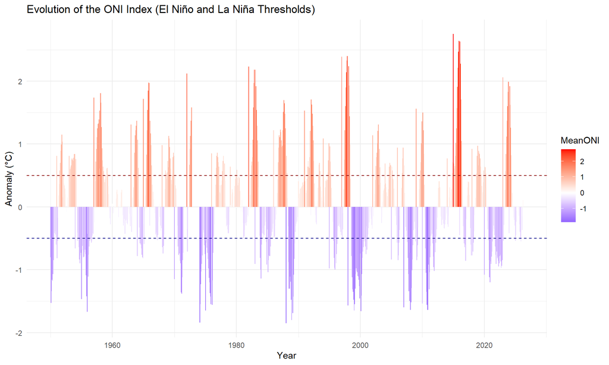

```r
df_oni <- df_recente %>% filter(!is.na(MeanONI)) %>% mutate(MeanONI = as.numeric(MeanONI)) %>%
  group_by(Ano, Mes) %>% summarise(MeanONI = mean(MeanONI, na.rm = TRUE),
                                   .groups = 'drop') %>%
  mutate(Data_Mes = make_date(Ano, Mes, 1)) %>% arrange(Data_Mes)

ggplot(df_oni, aes(x = Data_Mes, y = MeanONI, fill = MeanONI)) +
  geom_col(width = 35) +
  scale_fill_gradient2(low = "blue", mid = "white", high = "red", midpoint = 0) +
  geom_hline(yintercept = 0.5, linetype = "dashed", color = "darkred") +
  geom_hline(yintercept = -0.5, linetype = "dashed", color = "darkblue") +
  labs(title = "Evolution of the ONI Index (El Niño and La Niña Thresholds)",
       x = "Year", y = "Anomaly (°C)") +
  theme_minimal()
```

## 14. Advanced ARIMA Forecast

```r
library(forecast)

ano_inicial <- min(as.numeric(df_oni$Ano))
mes_inicial <- min(as.numeric(df_oni$Mes[df_oni$Ano == ano_inicial]))

ts_oni <- ts(df_oni$MeanONI, start = c(ano_inicial, mes_inicial),
             frequency = 12)

modelo_arima <- auto.arima(ts_oni)

cat("\n--- Summary of Automatically Chosen ARIMA Model ---\n")
```

```
##
## --- Summary of Automatically Chosen ARIMA Model ---
```

```r
print(summary(modelo_arima))
```

```
## Series: ts_oni
## ARIMA(3,0,3)(1,0,2)[12] with zero mean
##
## Coefficients:
##          ar1      ar2     ar3      ma1     ma2      ma3     sar1     sma1
##       2.5924  -2.4853  0.8766  -2.1538  1.8062  -0.5125  -0.4706  -0.0357
## s.e.  0.0528   0.0779  0.0319   0.0539  0.0667   0.0368   0.1087   0.1018
##          sma2
##       -0.4170
## s.e.   0.0574
##
## sigma^2 = 0.2504:  log likelihood = -647.22
## AIC=1314.44   AICc=1314.69   BIC=1362.38
##
## Training set error measures:
##                      ME      RMSE       MAE MPE MAPE      MASE       ACF1
## Training set 0.01189226 0.4978775 0.3246306 NaN  Inf 0.3523594 0.01219477
```

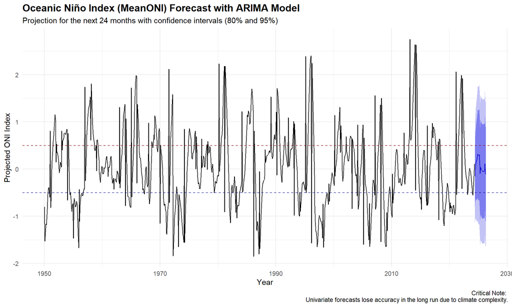

```r
# Forecasting
# We will predict the next 24 months (2 years)
previsao_oni <- forecast(modelo_arima, h = 24)

# Visualizing the Forecast
grafico_previsao <- autoplot(previsao_oni) +
  geom_hline(yintercept = 0.5, linetype = "dashed",
             color = "darkred", alpha = 0.7) +
  geom_hline(yintercept = -0.5, linetype = "dashed", color = "darkblue", alpha = 0.7) +
  labs(
    title = "Oceanic Niño Index (MeanONI) Forecast with ARIMA Model",
    subtitle = "Projection for the next 24 months with confidence intervals (80% and 95%)",
    x = "Year",
    y = "Projected ONI Index",
    caption = "Critical Note:
    Univariate forecasts lose accuracy in the long run due to climate complexity."
  ) +
  theme_minimal() +
  theme(plot.title = element_text(face = "bold", size = 14))

print(grafico_previsao)
```

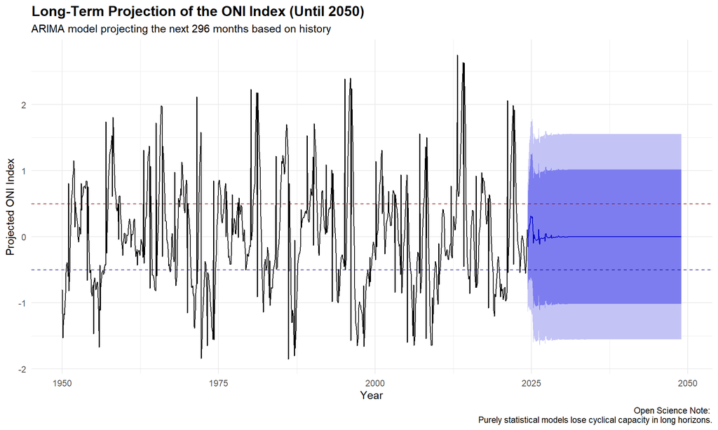

```r
# 1. Ensure required packages are active
library(forecast)
library(lubridate)

# 2. Time Series (ts) Object Creation
ano_inicial <- min(as.numeric(df_oni$Ano))
mes_inicial <- min(as.numeric(df_oni$Mes[df_oni$Ano == ano_inicial]))

ts_oni <- ts(df_oni$MeanONI, start = c(ano_inicial, mes_inicial), frequency = 12)

# 3. Adjusting the ARIMA Model
modelo_arima <- auto.arima(ts_oni)

# 4. Dynamic Calculation of Forecast Horizon (h) until December 2050
# Identifies the last available date in the historical series
ultima_data <- max(df_oni$Data_Mes)

# Calculates the exact number of months needed to reach the end of 2050
meses_ate_2050 <- (2050 - year(ultima_data)) * 12 + (12 - month(ultima_data))

# 5. Long-Term Forecasting
previsao_oni_2050 <- forecast(modelo_arima, h = meses_ate_2050)

# 6. Expanded Chart Visualization
grafico_previsao_2050 <- autoplot(previsao_oni_2050) +
  geom_hline(yintercept = 0.5, linetype = "dashed",
             color = "darkred", alpha = 0.7) +
  geom_hline(yintercept = -0.5, linetype = "dashed",
             color = "darkblue", alpha = 0.7) +
  labs(
    title = "Long-Term Projection of the ONI Index (Until 2050)",
    subtitle = paste("ARIMA model projecting the next", meses_ate_2050,
                     "months based on history"),
    x = "Year",
    y = "Projected ONI Index",
    caption = "Open Science Note:
    Purely statistical models lose cyclical capacity in long horizons."
  ) +
  theme_minimal() +
  theme(
    plot.title = element_text(face = "bold", size = 14)
  )

# Display the chart
print(grafico_previsao_2050)
```

**Interpretation:** Statistically, the ARIMA model shows us that it is impossible to predict whether the year 2050 will have an El Niño or La Niña using only the index’s past. The convergence of the line towards zero and the total widening of the margin of error prove that the climate is a dynamic and complex system that requires coupled physical models for long-term forecasts.

## 15. Advanced Forecast: Machine Learning with Prophet (Meta)

To project the future behavior of the Pacific Ocean robustly and resistant to *outliers*, we use the **Prophet** model.

[figure not shown]

```r
# Preparation in the format required by the Prophet package ('ds' and 'y')
df_prophet <- df_oni %>% select(Data_Mes, MeanONI) %>%
  rename(ds = Data_Mes, y = MeanONI)

# Model Training
modelo_prophet <- prophet(df_prophet, daily.seasonality=FALSE, weekly.seasonality=FALSE)

# Future DataFrame creation (next 24 months)
futuro_oni <- make_future_dataframe(modelo_prophet,
                                    periods = 24, freq = 'month')

# Prediction
previsao_prophet <- predict(modelo_prophet, futuro_oni)

# Overall Forecast Chart
plot(modelo_prophet, previsao_prophet) +
  geom_hline(yintercept = 0.5, linetype = "dashed", color = "darkred") +
  geom_hline(yintercept = -0.5, linetype = "dashed", color = "darkblue") +
  labs(title = "ONI Index Forecast using Prophet", x = "Year", y = "ONI Index") +
  theme_minimal()
```

### 15.1 Seasonal Components of the Prophet Model

One of the great advantages of modern *Data Science* is the ability to decompose the components of predictions.

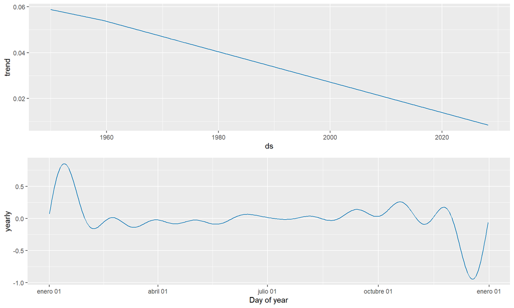

```r
prophet_plot_components(modelo_prophet, previsao_prophet)
```